# R的假设检验之一

李峰

四月 12, 2017

#### 1. 独立样本的均值差异检验

##### 1.1 理论依据

- 若总体方差$\sigma_1^2$和$\sigma_2^2$未知，但由经验可知相等，则$\sigma^2_{x_1-x_2}$的理论估计为：

$$\begin{equation}\label{eq:1}
\sigma^2_{x_1-x_2} = \frac{S_p}{n_1}+ \frac{S_p}{n_2},
\end{equation}$$
其中，
$$\begin{equation}\label{eq:2}
S_p = \frac{(n_1-1)S_1^2+(n_2-1)S_2^2}{n_1+n_2-2},
\end{equation}$$

称为合并方差。

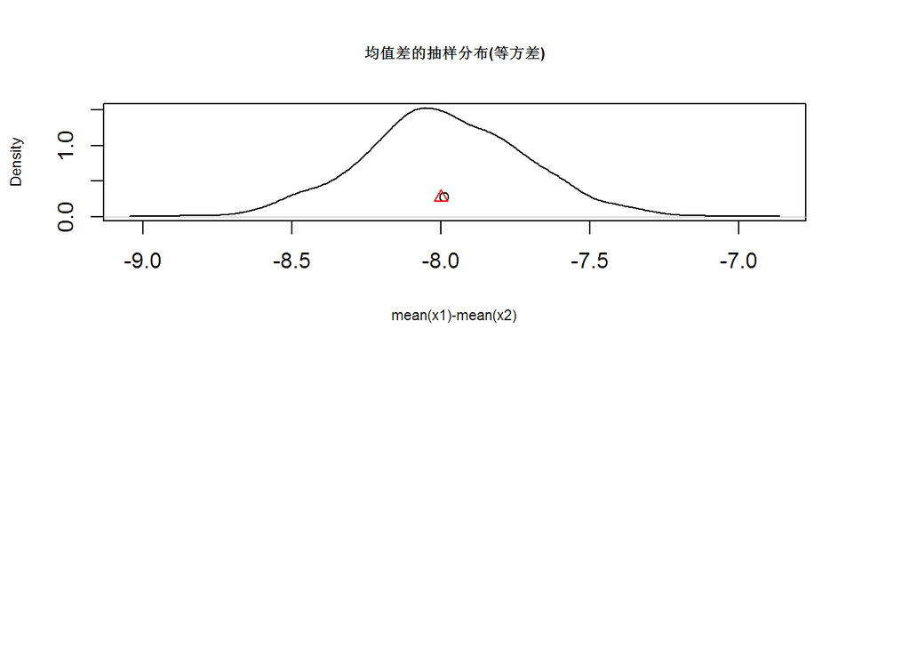

```r
par(mfrow=c(2,1),mar=c(4,4,4,4))
set.seed(12345)
Pop1<-rnorm(10000,mean=2,sd=2)   ###两总体方差相等
Pop2<-rnorm(10000,mean=10,sd=2)
Diff<-vector()
Sdx1<-vector()
Sdx2<-vector()
for(i in 1:2000){
 x1<-sample(Pop1,size=100,replace=TRUE)
 x2<-sample(Pop2,size=120,replace=TRUE)
 Diff<-c(Diff,(mean(x1)-mean(x2)))
 Sdx1<-c(Sdx1,sd(x1))
 Sdx2<-c(Sdx2,sd(x2))
}
plot(density(Diff),xlab="mean(x1)-mean(x2)",ylab="Density",main="均值差的抽样分布(等方差)",cex.main=0.7,cex.lab=0.7)
points(mean(Diff),sd(Diff),pch=1,col=1)
S1<-mean(Sdx1)
S2<-mean(Sdx2)
Sp<-((100-1)*S1^2+(120-1)*S2^2)/(100+120-2)
points((2-10),sqrt(Sp/100+Sp/120),pch=2,col=2)
```

- 若总体方差$\sigma_1^2$和$\sigma_2^2$未知且不相等时，则$\sigma^2_{x_1-x_2}$的理论估计为：

$$\begin{equation}\label{eq:3}
\sigma^2_{x_1-x_2} = \frac{S_1}{n_1}+ \frac{S_2}{n_2},
\end{equation}$$

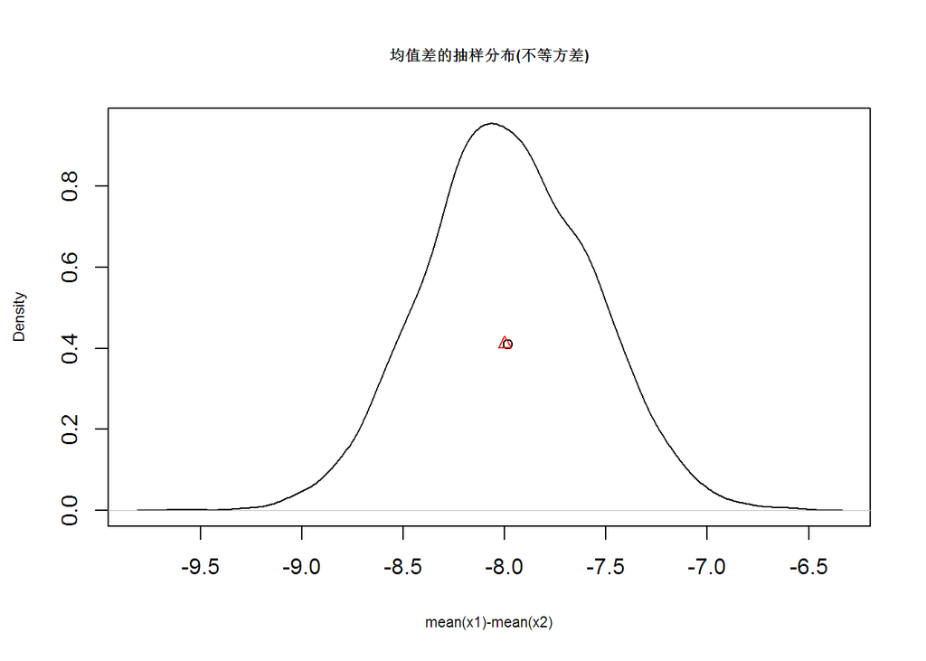

```r
set.seed(12345)
Pop1<-rnorm(10000,mean=2,sd=2)    ###两总体方差不等
Pop2<-rnorm(10000,mean=10,sd=4)
Diff<-vector()
Sdx1<-vector()
Sdx2<-vector()
for(i in 1:2000){
 x1<-sample(Pop1,size=100,replace=TRUE)
 x2<-sample(Pop2,size=120,replace=TRUE)
 Diff<-c(Diff,(mean(x1)-mean(x2)))
 Sdx1<-c(Sdx1,sd(x1))
 Sdx2<-c(Sdx2,sd(x2))
 }
plot(density(Diff),xlab="mean(x1)-mean(x2)",ylab="Density",main="均值差的抽样分布(不等方差)",cex.main=0.7,cex.lab=0.7)
points(mean(Diff),sd(Diff),pch=1,col=1)
S1<-mean(Sdx1)
S2<-mean(Sdx2)
points((2-10),sqrt(S1^2/100+S2^2/120),pch=2,col=2)
```

方差不等时，Welch提出仍采用$\frac{\bar{x}_1-\bar{x}_2}{\sigma_{x_1-x_2}}$作为统计量，但并不服从自由度为$n_1+n_2-2$的t分布，而是服从自由度为：

$$\begin{equation}\label{eq:4}
df = \frac{(\frac{S^2_1}{n_1}+\frac{S^2_2}{n_2})^2}{\frac{(\frac{S^2_1}{n_1})^2}{n_1-1}+\frac{(\frac{S^2_2}{n_2})^2}{n_2-1}},
\end{equation}$$

的t分布，再依据t分布进行统计判断，即Welch调整。

以上可以形成一个自动化的部分。

```r
varequ<-leveneTest(Tmp$temp,Tmp$month, center=mean)
varequp<-varequ$`Pr(>F)`[1]
if (varequp>=.05) t.test(temp~month,data=Tmp,paired=FALSE,var.equal=TRUE) else{
  t.test(temp~month,data=Tmp,paired=FALSE,var.equal=FALSE)
}
```

```
##
##  Two Sample t-test
##
## data:  temp by month
## t = -4.8063, df = 184, p-value = 3.184e-06
## alternative hypothesis: true difference in means is not equal to 0
## 95 percent confidence interval:
##  -23.106033  -9.657011
## sample estimates:
## mean in group jan mean in group aug
##           5.25000          21.63152
```

#### 2. 配对样本的均值差异检验

配对样本的均值差异检验本质上是单样本的t检验问题。即，可以将一一对应的观测值求差，得到差值样本，若差值样本的均值和0有显著差异，则认为配对样本的两总体的均值差有显著差异，反之则不显著。 即，对于单样本的t检验：

$$\begin{equation}\label{eq:5}
t=\frac{\bar{x}}{S/\sqrt{n}},
\end{equation}$$
$$\begin{equation}\label{eq:6}
t=\frac{\bar{D}}{S_D/\sqrt{n}},
\end{equation}$$

可以先得到差值样本，然后用将其和0比较：

```r
Diff<-ReportCard$chi-ReportCard$math
t.test(Diff,mu=0)
```

```
##
##  One Sample t-test
##
## data:  Diff
## t = 11.752, df = 58, p-value < 2.2e-16
## alternative hypothesis: true mean is not equal to 0
## 95 percent confidence interval:
##  18.34417 25.87617
## sample estimates:
## mean of x
##  22.11017
```

也可以直接使用函数：

```r
ReportCard<-read.table(file="ReportCard.txt",header=TRUE,sep=" ")
ReportCard<-na.omit(ReportCard)
t.test(ReportCard$chi,ReportCard$math,paired=TRUE)
```

```
##
##  Paired t-test
##
## data:  ReportCard$chi and ReportCard$math
## t = 11.712, df = 57, p-value < 2.2e-16
## alternative hypothesis: true difference in means is not equal to 0
## 95 percent confidence interval:
##  18.48871 26.11474
## sample estimates:
## mean of the differences
##                22.30172
```

#### 3. 关于效应值

一类错误为弃真错误，即$\alpha$水平，二类错误为取伪错误，即$\beta$。$1-\beta$为正确否定原假设的概率，即虚无假设是错的，而且你正确否定了。 $\beta$。$1-\beta$的大小取决于几个因素：

1. $\alpha$越大，则$1-\beta$越大；

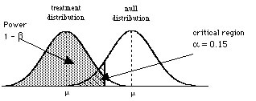

2. 均值差异的大小，若均值差异很大，则两个分布间重叠程度低，$1-\beta$会增大；

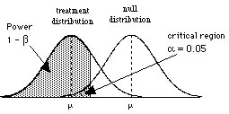

3. 样本大小也是很重要的因素，样本越大，方差减小，则$1-\beta$会增大。

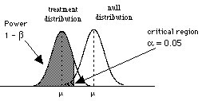

4. 单侧还是双侧检验也有影响，因双侧检验时，是用$p/2$和$\alpha$进行比较。

给定$\alpha$和$n$，并且规定了检验方向时，可以通过判断均值差异的大小判断两个分部间的重叠程度，判定其统计功效，即$1-\beta$的大小。

在样本均值差异的功效分析中，R采用Cohen提出的效应量定义。 对独立样本t检验，其效应量为：

$$\begin{equation}\label{eq:7}
ES=\frac{|\bar{x}_1-\bar{x}_2|}{\sqrt{\frac{S^2_1+S^2_2}{2}}},
\end{equation}$$

配对样本均值t检验的效应量为：

$$\begin{equation}\label{eq:8}
ES=\frac{|\bar{D}|}{S_{\bar{D}}},
\end{equation}$$
单样本t检验的效应量为：
$$\begin{equation}\label{eq:9}
ES=\frac{|\bar{x}-\mu_0|}{S},
\end{equation}$$

根据Cohen的研究，ES的值0.2时效应量比较小，取0.5时中等，取0.8时比较大。

在R里，用*pwr*包来实现统计功效的计算。样本量相同时，用**pwr.t.test**，样本量不相同时，用**pwr.t2n.test**。

```r
# install.packages("pwr")
library("pwr")
pwr.t2n.test(n1=2,n2=184,d=4.8,sig.level=0.05,alternative="two.sided")
```

```
##
##      t test power calculation
##
##              n1 = 2
##              n2 = 184
##               d = 4.8
##       sig.level = 0.05
##           power = 0.999999
##     alternative = two.sided
```

也可以让上述程序自动化

```r
Des.Fun<-function(x,...){
 Av<-mean(x,na.rm=TRUE)
 Var<-var(x,na.rm=TRUE)
 N<-length(x[!is.na(x)])
 result<-list(avg=Av,var=Var,n=N)
 return(result)
}
temp.month<-tapply(Tmp$temp,INDEX=Tmp$month,FUN=Des.Fun,na.rm=TRUE)
ES<-abs(temp.month$jan$avg-temp.month$aug$avg)/(sqrt((temp.month$jan$var+temp.month$aug$var)/2))
pwr.t2n.test(n1=temp.month$jan$n,n2=temp.month$aug$n,d=ES,sig.level=0.05,alternative="two.sided")
```

```
##
##      t test power calculation
##
##              n1 = 2
##              n2 = 184
##               d = 4.818646
##       sig.level = 0.05
##           power = 0.9999991
##     alternative = two.sided
```

对于学生成绩，前面配对样本t检验的结果是语文和数学成绩存在显著差异，如果这是一个正确的决策，那么在$\alpha=0.05$的情况下，统计功效达到0.8且n=58时，ES至少应多大？

```r
pwr.t.test(n=58,sig.level=0.05,power=0.8,type="paired",alternative="two.sided")
```

```
##
##      Paired t test power calculation
##
##               n = 58
##               d = 0.3742143
##       sig.level = 0.05
##           power = 0.8
##     alternative = two.sided
##
## NOTE: n is number of *pairs*
```

试着让上述程序自动化？判断在例子中，正确拒绝虚无假设的概率是否大于0.8？

- 相关系数的统计效应分析

```r
ReportCard<-read.table(file="ReportCard.txt",header=TRUE,sep=" ")
Tmp<-ReportCard[complete.cases(ReportCard),]
corr<-cor.test(Tmp[,5],Tmp[,7],alternative="two.side",method="pearson")
library("pwr")
pwr.r.test(r=corr$estimate,sig.level=0.05,n=(corr$parameter+2),alternative="two.sided")
```

```
##
##      approximate correlation power calculation (arctangh transformation)
##
##               n = 58
##               r = 0.7535317
##       sig.level = 0.05
##           power = 1
##     alternative = two.sided
```

- chi-square的功效分析

其效应量是：

$$\begin{equation}\label{eq:10}
ES=\sqrt{\sum_{i=1}^{rc}\frac{(p^o_i-p^e_i)^2}{p^e_i}}=\sqrt{\frac{\chi^2}{n}},
\end{equation}$$

即$\phi$系数。

```r
(CrossTable<-table(Tmp[,c(2,12)]))
```

```
##    avScore
## sex  B  C  D  E
##   F  2 13 10  3
##   M  2 11 12  5
```

```r
(ResChisq<-chisq.test(CrossTable,correct=FALSE))
```

```
##
##  Pearson's Chi-squared test
##
## data:  CrossTable
## X-squared = 0.78045, df = 3, p-value = 0.8541
```

```r
(phi<-sqrt(ResChisq$statistic/nrow(Tmp)))
```

```
## X-squared
##     0.116
```

```r
library("pwr")
(chip<-pwr.chisq.test(sig.level=0.05,N=nrow(Tmp),power=0.9,df=ResChisq$parameter))
```

```
##
##      Chi squared power calculation
##
##               w = 0.4943029
##               N = 58
##              df = 3
##       sig.level = 0.05
##           power = 0.9
##
## NOTE: N is the number of observations
```

```r
if (phi<chip$w) print("power小于0.9") else{
  print("power大于0.9")
}
```

```
## [1] "power小于0.9"
```